# Deep Learning for News Dataset Classification

In this notebook, I applied Deep Learning using Recurrent Neural Network (RNN) with Long Short Term Memory (LSTM) to classify news datasets. The architecture can be seen in the image below.

[figure not shown]

## Data Preparation

```python
# Download dataset
import requests
url = "http://bdsrc.binus.ac.id/wawan/uasdl/news.csv"
req = requests.get(url)

with open("news.csv", "wb") as f:
  f.write(req.content)
```

```python
# Import dataset
import pandas as pd
original_data = pd.read_csv("news.csv")
original_data.head()
```

|  | title | text | category |
| --- | --- | --- | --- |
| 0 | moeldoko harap seni budaya bisa jadi magnet ku... | Kepala Staf Kepresidenan RI Jenderal TNI (Pur... | Culture |
| 1 | seniman palestina sulap tembakan israel jadi k... | Berbeda dari seniman pada umumnya, seorang se... | Culture |
| 2 | sontek cara 56 kreator berpengaruh di dunia ci... | , menjadi modal utama yang harus dimiliki tia... | Culture |
| 3 | intip pertunjukan fashion dalam balutan seni t... | Dari Sabang sampai Merauke, Indonesia menawar... | Culture |
| 4 | kenang benyamin sueb teater abnon gelar pement... | Benyamin Suaeb bukan hanya sekadar nama. Soso... | Culture |

From what I have analyzed, I have found news stories that had erratic punctuation, such as ".," or ",.", etc. I also found some data that has a watermark which says, "Copyright © 2018, KLY KapanLagi Youniverse All Rights Reserved". Although this does not need to be removed because this data is in the same classification, namely Culture, it would be better to remove this watermark to create cleaner data. To see some text, you can run `text_checking` according to the parameters that have been set

```python
# Print sample text data by random
# indexing for given print sample number
def text_checking(dataset, num_of_print):
  import random

  for it in range(num_of_print):
    index = random.randint(0, dataset.shape[0] - 1)
    print("Text with index " + str(index) + ":\n" + dataset[index])

text_checking(original_data["text"], 10)
```

```
Text with index 49:
 Sukses menggelar pameran di berbagai negara, kini pameran seni rupa "Yayoi Kusama: Life is The Heart of Rainbow" hadir di Jakarta, tepatnya di Museum of Modern and Contemporary Art at Nusantara (,) pada 12 Mei hingga 9 September 2018.,Digelarnya pameran Yayoi Kusama inipun disambut antusiasme yang …
Text with index 68:
 pun pasti merasakan suatu tekanan ketika bekerja. Akan tetapi, kadang-kadang tekanan itu bisa berat, sedang atau biasa-biasa saja.  Bila tekanan itu dirasakan berat, hali itu tentu akan membuat Anda mudah marah, letih, dan tidak produktif.,Untuk memeriksa tingkat stres Anda ketika bekerja, ada sebu…
Text with index 49:
 Sukses menggelar pameran di berbagai negara, kini pameran seni rupa "Yayoi Kusama: Life is The Heart of Rainbow" hadir di Jakarta, tepatnya di Museum of Modern and Contemporary Art at Nusantara (,) pada 12 Mei hingga 9 September 2018.,Digelarnya pameran Yayoi Kusama inipun disambut antusiasme yang …
Text with index 89:
- HIV/AIDS di Indonesia memasuki tingkat epidemi terkonsentrasi, dengan jumlah penderita yang terus mengalami peningkatan. "Penderita secara komulatif penderita AIDS tercatat 11.141 kasus dan HIV 6.066 kasus," kata Ajianto dari Komisi Penanggulangan AIDS Nasional (KPAN) di Denpasar, Sabtu (19/7).,Me…
Text with index 91:
 Dr. Boyke Dian Nugraha menyarankan masyarakat untuk ikut membantu mencegah dan menekan penularan penyakit HIV/AIDS. Menurutnya, ada lima langkah yang dapat dilakukan guna mencegah penularan penyakit yang mematikan dan belum ada obatnya tersebut.,    ,"Yang pertama adalah menghindari berhubungan sek…
Text with index 34:
 Seorang pemain perkusi ternama dari ,, Park Je Chun menampilkan karyanya di Indonesian Dance Festival 2016 beberapa waktu lalu. Dengan karyanya yang berjudul “Do You Want Me”, Park Je Chun berkolaborasi dengan tujuh penari dari dua negara, tiga penari Korea Selatan dan empat penari Indonesia. Pertu…
Text with index 68:
 pun pasti merasakan suatu tekanan ketika bekerja. Akan tetapi, kadang-kadang tekanan itu bisa berat, sedang atau biasa-biasa saja.  Bila tekanan itu dirasakan berat, hali itu tentu akan membuat Anda mudah marah, letih, dan tidak produktif.,Untuk memeriksa tingkat stres Anda ketika bekerja, ada sebu…
Text with index 68:
 pun pasti merasakan suatu tekanan ketika bekerja. Akan tetapi, kadang-kadang tekanan itu bisa berat, sedang atau biasa-biasa saja.  Bila tekanan itu dirasakan berat, hali itu tentu akan membuat Anda mudah marah, letih, dan tidak produktif.,Untuk memeriksa tingkat stres Anda ketika bekerja, ada sebu…
Text with index 97:
 - Penderita HIV/AIDS di Bali secara kumulatif hingga Maret 2008 mencapai 1.986 kasus, meningkat 345 penderita dibanding periode sama tahun sebelumnya yang tercatat 1.641 orang.,    ,Jumlah penderita tersebut menempatkan posisi Bali pada urutan lima besar nasional, kata Koordinator Program Komisi Pe…
Text with index 6:
 , menjadi sebuah media yang mampu memberikan pesan sekaligus hiburan menarik bagi para penontonnya. Hal ini juga disadari betul oleh para pemuda pemudi dari HKBP Kebayoran Baru, yang merayakan Hari Kebangkitan Pemuda Harheheon 2017. Mereka menyajikan sebuah pertunjukan teatrikal, musik, dan tari da…
```

## Data Preprocessing

In data preprocessing, I did two tokenization processes. The first was tokenization which was made by myself. This was done to control some tokenizations that Keras Tokenizer cannot execute, i.e.:

- Remove empty spaces that was found after punctuation tokenization. Example:  
  ", Penunjang kualitas pendidikan" -> " Penunjang kualitas pendidikan" -> "Penunjang kualitas pendidikan"
- Remove watermark "Copyright © 2018 , KLY KapanLagi Youniverse All Rights Reserved"
- Trim more than one space and spaces at the beginning and end of paragraphs.

```python
# My custom text preprocessing
import re
def preprocessing_text_custom(text):
  regex = "Copyright © 2018 , KLY KapanLagi Youniverse All Rights Reserved"
  final_text = re.sub(regex, '', text)
  final_text = re.sub('[!"#$%&()*+,-./:;“”<=>?@[\\]^_`{|}~\t\n\d]', ' ', final_text)
  final_text = re.sub("\s+", " ", final_text)
  final_text = final_text.strip()

  return final_text
```

```python
original_data["text_cleaned"] = original_data['text'].apply(preprocessing_text_custom)
```

```python
# Divide data into features and labels
DATA_LENGTH = original_data.shape[0]
X_data, y_data = original_data["text_cleaned"].to_numpy(), original_data["category"].to_numpy()
y_data = y_data.reshape((DATA_LENGTH, 1))
```

```python
# Text preprocessing from Keras Tokenizer
from keras.preprocessing.text import Tokenizer
tokenizer = Tokenizer(filters='!"#$%&()*+,-./:;“”\'<=>?@[\\]^_`{|}~\t\n', lower=True, split=' ')
tokenizer.fit_on_texts(X_data)

X_data_sequences = tokenizer.texts_to_sequences(X_data)
```

```python
# List Index to Word
idx_to_word = tokenizer.index_word

# Print sample for sequence to text converter
def sequence_to_text_checking(sequences, index_to_word, num_of_print):
  import random

  for it in range(num_of_print):
    index = random.randint(0, len(sequences) - 1)
    seq_to_text = ' '.join([ index_to_word[i] for i in sequences[index] ])
    print("Text with index " + str(index) + ":\n" + seq_to_text)

sequence_to_text_checking(X_data_sequences, idx_to_word, 5)
```

```
Text with index 84:
hiv aids mengancam kehidupan masyarakat kabupaten boven digoel papua yang terletak di wilayah perbatasan republik indonesia ri dengan papua nugini png sebagai wilayah perbatasan dengan tingkat mobilitas penduduk yang tinggi masyarakat di boven digoel sangat rentan akan penyebaran hiv aids sehingga k…
Text with index 90:
tumbuh bila daya tahan tubuhnya kuat saluran cerna dalam hal ini merupakan portal penting yang perlu dijaga dan dipelihara kesehatannya demikian diungkapkan rienani mahadi praktisi gizi nestle indonesia rabu bila anda ingin agar anak menjadi cerdas perlu dipahami bahwa kecerdasan anak bertumbuh akib…
Text with index 50:
cardiac resynchronization therapy tiba tiba menjadi akrab di telinga kita setelah berbagai media massa ramai memberitakan keadaan kesehatan mantan presiden soeharto yang dianggap memerlukan pemasangan crt tulisan ini mengulas apa sebenarnya crt apa indikasi penggunaannya bagaimana cara pemasangannya…
Text with index 70:
penyakit aids dan infeksi hiv di asia tempaknya makin memprihatinkan dan mengancam pertumbuhan ekonomi di wilayah ini kekhawatiran ini tidak terlepas dari fakta di lapangan bahwa saat ini ada lebih dari juta wanita di asia bekerja sebagai penjaja seks dan sedikitnya juta pria menjadi pelanggan setia…
Text with index 35:
menjelang imlek persiapan permainan barongsai dan liong sudah dimulai menjelang imlek persiapan permainan barongsai dan liong sudah dimulai
```

```python
# One Hot Encoding for Label
from sklearn.preprocessing import OneHotEncoder
ohe = OneHotEncoder(sparse=False)
y_data = ohe.fit_transform(y_data)
```

```python
# Split data into train and validation
from sklearn.model_selection import train_test_split
X_train, X_valid, y_train, y_valid = train_test_split(X_data_sequences, y_data, test_size=0.1, random_state=50)
```

Here I do the sequence again for the data sequence. This is taken to achieve consistency of the input data that will be used to train the model because the model I will use must have a fixed number of inputs. In addition, the sequence that I use is useful for records that have data that has an amount below the `MAX_LEN` that I specify where later for this record will be given a padding to fill the remaining space.

```python
from keras.preprocessing import sequence
MAX_LEN = 150
X_train = sequence.pad_sequences(X_train, maxlen=MAX_LEN)
X_valid = sequence.pad_sequences(X_valid, maxlen=MAX_LEN)
```

## Deep Learning Model

For the model, I used the Embedding model with 200 data features. Then, I trained the embedding results with Recurrent Neural Network (RNN) combined with Long Short Term Memory (LSTM) of 64 layers. Then, I used Dense layer of 64 using ReLU as my activation function. After that, I used Dropout with a value of 0.2. I used Dense and Dropout for once again with each of them has 128 layers and a value of 0.5. Finally, I used Dense for 2 layers with softmax activation considering this is the output value issued. Then, I used Adam Optimizer to optimize my model and use categorical cross entropy as loss control. This can be done using binary cross entropy but considering I'm using a one hot encoder, I can't use this. For the complete model, you can see below.

[figure not shown]

```python
NUM_OF_WORDS = len(tokenizer.word_index) + 1

from keras.models import Sequential
from keras.layers import LSTM, Dense, Dropout, Embedding
model = Sequential()
model.add(Embedding(NUM_OF_WORDS, 200, input_length=MAX_LEN))
model.add(LSTM(64, return_sequences=False, dropout=0.1, recurrent_dropout=0.1))
model.add(Dense(64, activation="relu"))
model.add(Dropout(0.2))
model.add(Dense(128, activation="relu"))
model.add(Dropout(0.5))
model.add(Dense(2, activation="softmax"))

model.summary()
model.compile(optimizer="adam", loss="categorical_crossentropy", metrics=["accuracy"])
```

```
WARNING:tensorflow:Layer lstm will not use cuDNN kernel since it doesn't meet the cuDNN kernel criteria. It will use generic GPU kernel as fallback when running on GPU
Model: "sequential"
_________________________________________________________________
Layer (type)                 Output Shape              Param #
=================================================================
embedding (Embedding)        (None, 150, 200)          1263200
_________________________________________________________________
lstm (LSTM)                  (None, 64)                67840
_________________________________________________________________
dense (Dense)                (None, 64)                4160
_________________________________________________________________
dropout (Dropout)            (None, 64)                0
_________________________________________________________________
dense_1 (Dense)              (None, 128)               8320
_________________________________________________________________
dropout_1 (Dropout)          (None, 128)               0
_________________________________________________________________
dense_2 (Dense)              (None, 2)                 258
=================================================================
Total params: 1,343,778
Trainable params: 1,343,778
Non-trainable params: 0
_________________________________________________________________
```

```python
history = model.fit(X_train, y_train, epochs=10, validation_data=(X_valid, y_valid))
```

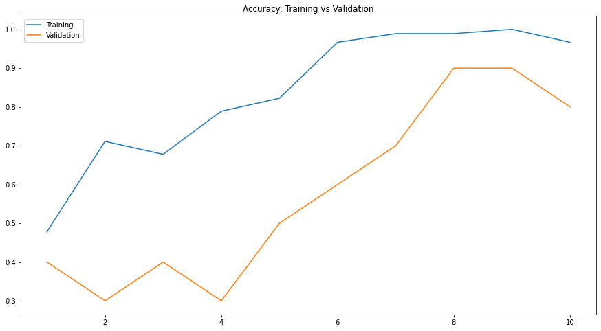

```python
import matplotlib.pyplot as plt
plt.figure(figsize=(15, 8))
plt.title("Accuracy: Training vs Validation")
plt.plot(range(1, 11), history.history["accuracy"], label="Training")
plt.plot(range(1, 11), history.history["val_accuracy"], label="Validation")
plt.legend()
plt.show()
```

From there, we can see that the model that I created tends to be overfitted at first with evidence that the distance between training and validation is quite far. However, starting from the 7th epoch the model began to improve with the accuracy values of training and validation getting closer. In my opinion, this model is good enough even though the preprocessing of the data is not perfect.